# Проект - Анализ данных и проверка гипотез

Популярный сервис аренды самокатов GoFast передал данные о некоторых пользователях из нескольких городов, а также об их поездках. Требуется проанализировать данные и проверить некоторые гипотезы, которые могут помочь бизнесу вырасти.

Чтобы совершать поездки по городу, пользователи сервиса GoFast пользуются мобильным приложением. В приложении есть подписка, и, тем самым, пользователи делятся на две категории те кто пользуются по общему тарифу, и те кто платят ежемесячную подписку.

Так как источником прибыли сервиса являются платежи в приложении, тарифы играют большую роль в бизнес логике, и как следствие на них потребуется обратить особое внимание.

**Цель исследования**

- Провести общий исследовательский анализ данных
- Проанализировать расстоянии и времени поездок для пользователей обеих категорий.
- Оценить прибыльность пользователей
- Проверить гипотезы о том как пользуются сервисом подписчики, и как это отличается от остальных пользователей
- Помочь отделу маркетинга оценить масштаб и вероятный результат рекламных акций
- Дать рекомендации по развитию бизнеса

**Ход исследования**

1. Загрузка данных - оценить качество и характеристики данных, ознакомится с ними.
2. Предобработка данных - по возможности, где целесообразно, найти и устранить аномалии в данных.
3. Исследовательский анализ данных. - Оценить общую информацию по пользователям и поездкам по ряду категорий.
4. Объединение данных - Собрать все данные в одну таблицу и разделить на две категории по подписке. Сравнить их длительность и время поездок.
5. Подсчёт выручки - Построить сводную таблицу чтобы оценить ежемесячную прибыль.
6. Проверка гипотез - Изучить поведение пользователей не предмет соответствия гипотезам заказчика.
7. Распределения - Оценить вероятную эффективность рекламных акций.
8. Общий вывод - Подытожить исследование. Дать рекомендации.

*Библиотеки. Параметры.*

**Содержание**

1. Шаг 1. Загрузка данных
2. Шаг 2. Предобработка данных  
   2.1. Пропуски  
   2.2. Явные дубликаты  
   2.3. Неявные дубликаты  
   2.4. Типы данных  
   2.5. Столбец `month`
3. Шаг 3. Исследовательский анализ данных  
   3.1. Частота встречаемости городов  
   3.2. Соотношение пользователей с подпиской и без подписки  
   3.3. Возраст пользователей  
   3.4. Расстояние, которое пользователь преодолел за одну поездку  
   3.5. Продолжительность поездок  
   3.6. Рассеяние продолжительности по дистанции  
   3.7. Скорость
4. Шаг 4. Объединение данных  
   4.1. Единый датафрейм  
   4.2. Таблицы: с подпиской и без  
   4.3. Визуализация
5. Шаг 5. Подсчёт выручки  
   5.1. Сборная таблица  
   5.2. Подсчёт выручки
6. Шаг 6. Проверка гипотез  
   6.1. Время с подпиской больше чем без  
   6.2. Не больше 3130 метров с подпиской  
   6.3. Выручка по месяцам с подпиской выше, чем без  
   6.4. Серверы мобильного приложения
7. Шаг 7. Распределения  
   7.1. Промокоды  
   7.2. Push-уведомления
8. Общий Вывод

```python
import pandas as pd
import seaborn as sns
import matplotlib.pyplot as plt
import numpy as np
import scipy.stats as st
import os
```

```python
sns.set_context("talk")
```

## 1. Шаг 1. Загрузка данных

```python
path_local = 'datasets/'
path_platform = '/datasets/'
path_extra = ''

df_list = [
    'users_go.csv',
    'rides_go.csv',
    'subscriptions_go.csv'
]

if os.path.exists(path_local) and all(list(map(os.path.exists, map(lambda x: path_local + x, df_list)))):
    df_dir = path_local
    print("Файлы найдены.")
elif os.path.exists(path_platform) and all(list(map(os.path.exists, map(lambda x: path_platform + x, df_list)))):
    df_dir = path_platform
    print("Файлы найдены.")
elif os.path.exists(path_extra) and all(list(map(os.path.exists, map(lambda x: path_extra + x, df_list)))):
    df_dir = path_extra
    print("Файлы найдены.")
elif all(list(map(os.path.exists, df_list))):
    df_dir = ''
    print("Файлы найдены.")
else:
    print("Директория не найдена. Файлы не найдены в текущей.")

udf = pd.read_csv(os.path.join(df_dir, 'users_go.csv'))
rdf = pd.read_csv(os.path.join(df_dir, 'rides_go.csv'))
sdf = pd.read_csv(os.path.join(df_dir, 'subscriptions_go.csv'))
```

```
Файлы найдены.
```

```python
print(udf.info())
udf.head()
```

```
<class 'pandas.core.frame.DataFrame'>
RangeIndex: 1565 entries, 0 to 1564
Data columns (total 5 columns):
 #   Column             Non-Null Count  Dtype
---  ------             --------------  -----
 0   user_id            1565 non-null   int64
 1   name               1565 non-null   object
 2   age                1565 non-null   int64
 3   city               1565 non-null   object
 4   subscription_type  1565 non-null   object
dtypes: int64(2), object(3)
memory usage: 61.3+ KB
None
```

|  | user_id | name | age | city | subscription_type |
| --- | --- | --- | --- | --- | --- |
| 0 | 1 | Кира | 22 | Тюмень | ultra |
| 1 | 2 | Станислав | 31 | Омск | ultra |
| 2 | 3 | Алексей | 20 | Москва | ultra |
| 3 | 4 | Константин | 26 | Ростов-на-Дону | ultra |
| 4 | 5 | Адель | 28 | Омск | ultra |

```python
print(rdf.info())
rdf.head()
```

```
<class 'pandas.core.frame.DataFrame'>
RangeIndex: 18068 entries, 0 to 18067
Data columns (total 4 columns):
 #   Column    Non-Null Count  Dtype
---  ------    --------------  -----
 0   user_id   18068 non-null  int64
 1   distance  18068 non-null  float64
 2   duration  18068 non-null  float64
 3   date      18068 non-null  object
dtypes: float64(2), int64(1), object(1)
memory usage: 564.8+ KB
None
```

|  | user_id | distance | duration | date |
| --- | --- | --- | --- | --- |
| 0 | 1 | 4409.919140 | 25.599769 | 2021-01-01 |
| 1 | 1 | 2617.592153 | 15.816871 | 2021-01-18 |
| 2 | 1 | 754.159807 | 6.232113 | 2021-04-20 |
| 3 | 1 | 2694.783254 | 18.511000 | 2021-08-11 |
| 4 | 1 | 4028.687306 | 26.265803 | 2021-08-28 |

```python
print(sdf.info())
sdf.head()
```

```
<class 'pandas.core.frame.DataFrame'>
RangeIndex: 2 entries, 0 to 1
Data columns (total 4 columns):
 #   Column             Non-Null Count  Dtype
---  ------             --------------  -----
 0   subscription_type  2 non-null      object
 1   minute_price       2 non-null      int64
 2   start_ride_price   2 non-null      int64
 3   subscription_fee   2 non-null      int64
dtypes: int64(3), object(1)
memory usage: 192.0+ bytes
None
```

|  | subscription_type | minute_price | start_ride_price | subscription_fee |
| --- | --- | --- | --- | --- |
| 0 | free | 8 | 50 | 0 |
| 1 | ultra | 6 | 0 | 199 |

**Вывод**

## 2. Шаг 2. Предобработка данных

### 2.1. Пропуски

Проверим пропуски.

```python
udf.isna().sum()
```

```
user_id              0
name                 0
age                  0
city                 0
subscription_type    0
dtype: int64
```

```python
rdf.isna().sum()
```

```
user_id     0
distance    0
duration    0
date        0
dtype: int64
```

**Вывод**

Явных пропусков нет.

### 2.2. Явные дубликаты

Проверим дубликаты.

```python
rdf.duplicated().sum()
```

```
0
```

Поездок - явных дубликатов нет.

```python
udf.duplicated().sum()
```

```
31
```

```python
udf[udf.duplicated()].head(5)
```

|  | user_id | name | age | city | subscription_type |
| --- | --- | --- | --- | --- | --- |
| 1534 | 293 | Агата | 26 | Краснодар | ultra |
| 1535 | 16 | Амалия | 27 | Краснодар | ultra |
| 1536 | 909 | Константин | 20 | Екатеринбург | free |
| 1537 | 403 | Полина | 19 | Сочи | ultra |
| 1538 | 908 | Рустам | 30 | Тюмень | free |

```python
len(udf)
```

```
1565
```

Есть полные дубликаты, список включает оба типа подписки и множество городов и пользователей. Скорее всего тех ошибка, отбросим.

```python
udf.drop_duplicates(inplace=True)
udf.duplicated().sum()
```

```
0
```

Проверим влияет ли тип подписки на дубликаты - убедимся что нет сбоя с самой подпиской который мог бы делать дубликаты.

```python
udf.drop(columns = 'subscription_type').duplicated().sum()
```

```
0
```

Тип подписки сам по себе не влияет. Уместно проверить есть ли дубликаты с разными `user_id` - возможно пользователи создали больше одного аккаунта, однако т.к. у нас есть только имя пользователя и нет фамилии и отчества, нельзя быть уверенным что это одни и те же люди.

```python
len(udf)
```

```
1534
```

```python
udf.duplicated(['name', 'age', 'city']).sum()
```

```
53
```

```python
100/(1534/53)
```

```
3.4550195567144724
```

**Вывод**

Удалось избавиться от 31 дубликатов, есть еще 53 записи где различается только тип подписки и идентификатор пользователя, однако из-за отсутствия более детальных данных о пользователях нельзя с уверенностью считать их дубликатами. В любом случае данное количество не должно значимо сказаться на общем качестве данных.

### 2.3. Неявные дубликаты

Данные о поездках содержат числа и даты, наличие неявных дубликатов там крайне маловероятно и тяжело быть уверенным совпадение или действительно две разные поездки.

А вот имена людей и названия городов в данных по пользователям могут оказаться введены неправильно - с ошибками, разницей регистра, и т.п. Ознакомимся с ними.

```python
udf.city.value_counts()
```

```
Пятигорск         219
Екатеринбург      204
Ростов-на-Дону    198
Краснодар         193
Сочи              189
Омск              183
Тюмень            180
Москва            168
Name: city, dtype: int64
```

```python
udf.name.value_counts().tail(20)
```

```
Таисия       4
Ирина        4
Игнат        4
Лилия        4
Ульяна       4
Василий      4
Полина       4
Эмилия       4
Мирослав     3
Сергей       3
Алина        3
Матвей       3
Леонид       3
Светлана     3
Илья         3
Елизавета    3
Семен        2
Милана       1
Тихон        1
Радмир       1
Name: name, dtype: int64
```

```python
sorted(udf.name.unique())
```

```
['Агата',
 'Аделина',
 'Адель',
 'Айдар',
 'Александр',
 'Александра',
 'Алексей',
 'Алина',
 'Алиса',
 'Алия',
 'Алла',
 'Альберт',
 'Альбина',
 'Алёна',
 'Амалия',
 'Амина',
 'Амир',
 'Анастасия',
 'Анатолий',
 'Ангелина',
 'Андрей',
 'Анжелика',
 'Анна',
 'Антон',
 'Антонина',
 'Ариана',
 'Арина',
 'Арсен',
 'Арсений',
 'Артемий',
 'Артур',
 'Артём',
 'Богдан',
 'Борис',
 'Вадим',
 'Валентина',
 'Валерий',
 'Валерия',
 'Варвара',
 'Василий',
```

[output cut: 139 more lines]

```
 'Эдуард',
 'Элина',
 'Эльвира',
 'Эльмира',
 'Эмилия',
 'Эмиль',
 'Юлиана',
 'Юлия',
 'Юрий',
 'Ян',
 'Яна',
 'Яромир',
 'Ярослав',
 'Ярослава',
 'Ясмина']
```

**Вывод**

Неявных дубликатов не наблюдается - пользователи проживают в 8 городах, все имена придерживаются одинакового регистра, имена с ё не повторяются.

Дубликаты и пропуски обработаны, сбросим индекс.

```python
udf.reset_index(drop=True, inplace=True)
```

### 2.4. Типы данных

Обработаем типы данных.

```python
udf.dtypes
```

```
user_id               int64
name                 object
age                   int64
city                 object
subscription_type    object
dtype: object
```

```python
rdf.dtypes
```

```
user_id       int64
distance    float64
duration    float64
date         object
dtype: object
```

```python
sdf.dtypes
```

```
subscription_type    object
minute_price          int64
start_ride_price      int64
subscription_fee      int64
dtype: object
```

Переведём int64 в int32 для сохранения памяти. Заменим подписку булевыми значениями. Переведём дату в формат даты `pandas`.

```python
udf['subscription_type'].replace({'free':False, 'ultra':True}, inplace=True)
sdf['subscription_type'].replace({'free':False, 'ultra':True}, inplace=True)
```

```python
udf[['user_id', 'age']] = udf[['user_id', 'age']].astype('int32')
rdf['user_id'] = rdf['user_id'].astype('int32')
sdf[['minute_price', 'start_ride_price', 'subscription_fee']] = \
    sdf[['minute_price', 'start_ride_price', 'subscription_fee']].astype('int32')
```

```python
rdf['date'] = pd.to_datetime(rdf['date'])
```

**Итого**

```python
udf.dtypes
```

```
user_id               int32
name                 object
age                   int32
city                 object
subscription_type      bool
dtype: object
```

```python
rdf.dtypes
```

```
user_id              int32
distance           float64
duration           float64
date        datetime64[ns]
dtype: object
```

```python
sdf.dtypes
```

```
subscription_type     bool
minute_price         int32
start_ride_price     int32
subscription_fee     int32
dtype: object
```

**Вывод**

Преобразование даты и подписки в `datetime` и `bool` позволит в дальнейшем более удобно работать с данными, а `int32` более чем достаточен для хранения информации порядков представленных в таблицах, хоть и не обязателен учитывая сравнительно маленький объём данных.

### 2.5. Столбец `month`

В рамках проекта требуется добавить столбец отражающий месяц на основе столбца `date`. Ознакомимся с периодом который представлен в `date` чтобы убедиться определить нужно ли учитывать год.

```python
[rdf.date.min(),rdf.date.max()]
```

```
[Timestamp('2021-01-01 00:00:00'), Timestamp('2021-12-30 00:00:00')]
```

Все значения из 2021 года, как следствие месяца можно добавлять не оглядываясь на год.

```python
rdf['month'] = rdf.date.dt.month
rdf.head()
```

|  | user_id | distance | duration | date | month |
| --- | --- | --- | --- | --- | --- |
| 0 | 1 | 4409.919140 | 25.599769 | 2021-01-01 | 1 |
| 1 | 1 | 2617.592153 | 15.816871 | 2021-01-18 | 1 |
| 2 | 1 | 754.159807 | 6.232113 | 2021-04-20 | 4 |
| 3 | 1 | 2694.783254 | 18.511000 | 2021-08-11 | 8 |
| 4 | 1 | 4028.687306 | 26.265803 | 2021-08-28 | 8 |

**Вывод**

Данный столбец позволит легче сортировать записи по месяцам. Он представляет отдельный интерес т.к. у нас подписка ежемесячная.

## 3. Шаг 3. Исследовательский анализ данных

**Подготовка данных для анализа.**

Требуется рассмотреть распределение данных о пользователях и поездках по ряду категорий. Объединим данные чтобы иметь более полную информацию о поездках. Для того чтобы это сделать проверим `shape` и `user_id`, чтобы убедится что мы не потеряем значения и не добавим пропуски.

```python
rdf.shape
```

```
(18068, 5)
```

```python
udf.shape
```

```
(1534, 5)
```

```python
all(rdf.user_id.sort_values().unique() == udf.user_id.sort_values().unique())
```

```
True
```

```python
crudf = rdf.merge(udf, on='user_id') # Complete Rides with User
```

```python
crudf.sample(5)
```

|  | user_id | distance | duration | date | month | name | age | city | subscription_type |
| --- | --- | --- | --- | --- | --- | --- | --- | --- | --- |
| 8615 | 857 | 3271.344891 | 15.545923 | 2021-11-10 | 11 | Лариса | 25 | Тюмень | False |
| 7326 | 758 | 4102.781163 | 20.205562 | 2021-02-07 | 2 | Федор | 26 | Ростов-на-Дону | False |
| 15512 | 1356 | 181.295471 | 2.988884 | 2021-02-24 | 2 | Эдуард | 25 | Омск | False |
| 10065 | 962 | 3571.391199 | 18.714174 | 2021-08-21 | 8 | Дмитрий | 39 | Москва | False |
| 12681 | 1152 | 2142.946770 | 12.571787 | 2021-06-28 | 6 | Альбина | 21 | Пятигорск | False |

```python
crudf.shape
```

```
(18068, 9)
```

**Вывод** Мы создали новую таблицу добавив к `rdf` (18068, 5) столбцы из `udf` (1534, 5) и получили `crudf` (18068, 9), который совпадает по длине с оригиналом и на 4 (т.е. 5-1) столбца шире, что и ожидалось.

### 3.1. Частота встречаемости городов

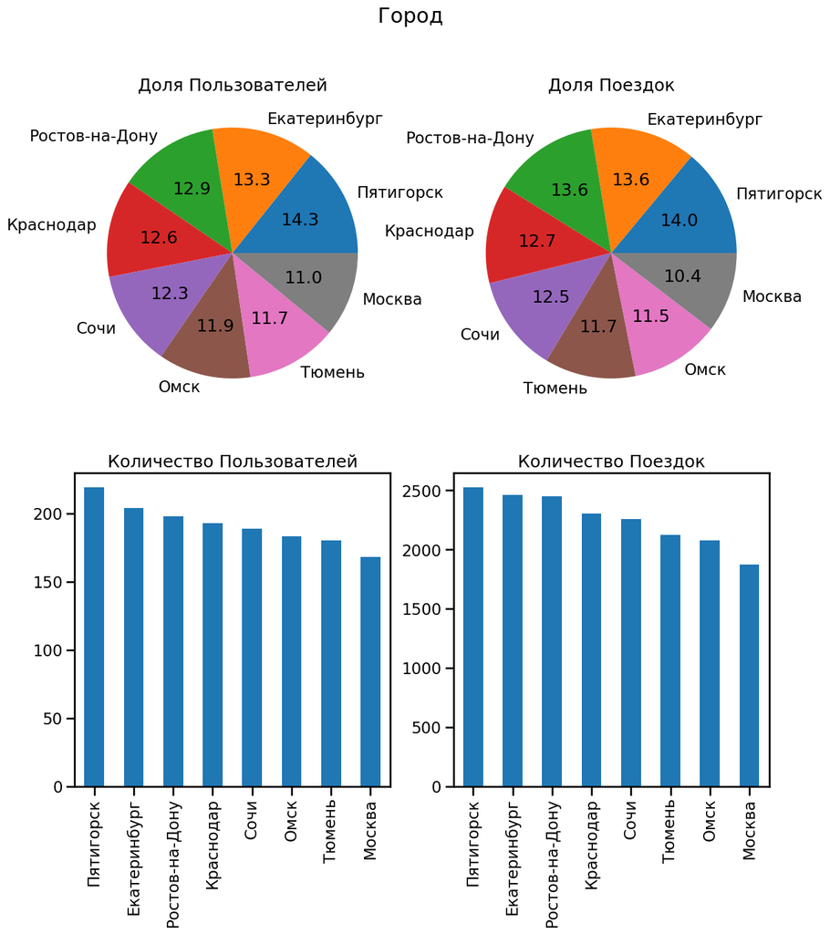

```python
fig1, ((ax1, ax2), (ax3, ax4)) = plt.subplots(2, 2, figsize=(13, 13))
fig1.suptitle('Город')
udf.city.value_counts().plot.pie(ylabel='', autopct='%.1f', title='Доля Пользователей', ax=ax1);
crudf.city.value_counts().plot.pie(ylabel='', autopct='%.1f', title='Доля Поездок', ax=ax2);
udf.city.value_counts().plot.bar(ylabel='', title='Количество Пользователей', ax=ax3);
crudf.city.value_counts().plot.bar(ylabel='', title='Количество Поездок', ax=ax4);
plt.show()
```

**Вывод**

Более менее равномерно распределены между исследуемыми городами, на удивление Москва - на последнем месте. Однако чем это вызвано сложно сказать. Возможно связано с факторами уменьшающими спрос: развитым публичным транспортом и метро, большим количеством личного транспорта, большими дистанциями. Возможно высокая конкуренция. Возможно также предоставленные данные не пропорциональны общему количеству пользователей в городах. Статистика поездок в целом пропорциональна пользователям.

### 3.2. Соотношение пользователей с подпиской и без подписки

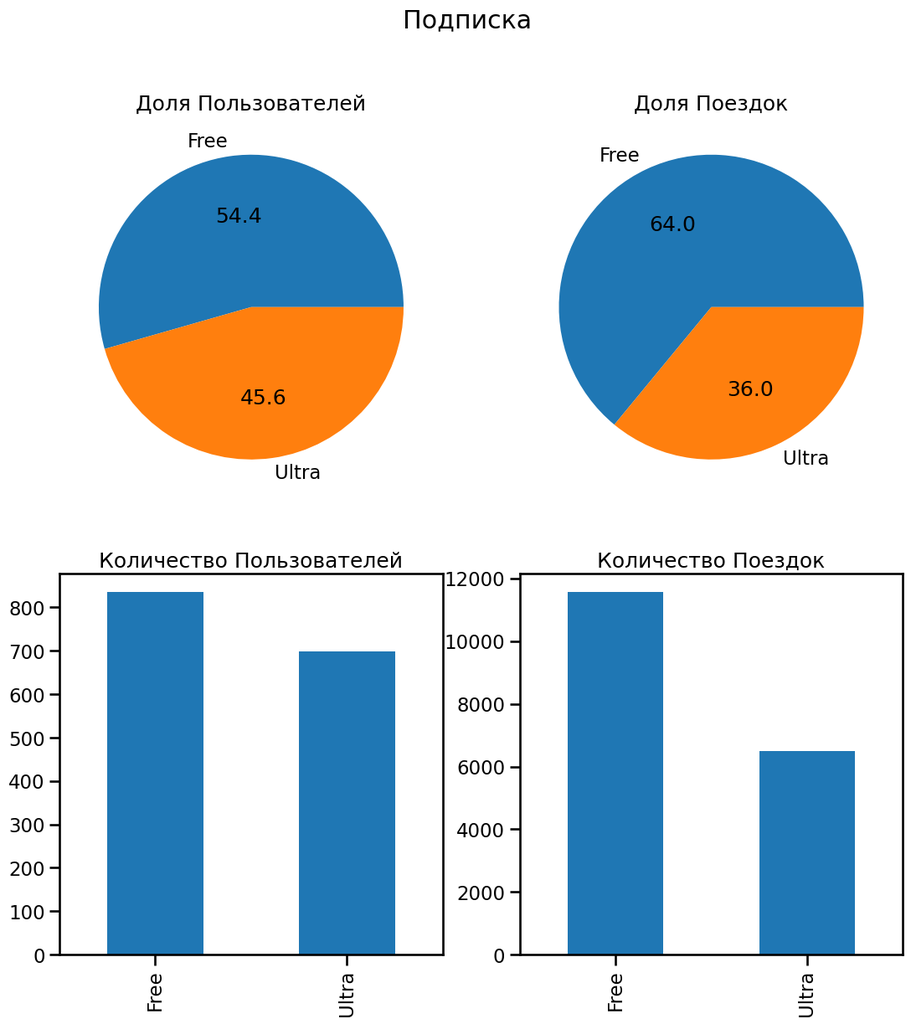

```python
fig1, ((ax1, ax2), (ax3, ax4)) = plt.subplots(2, 2, figsize=(13, 13))
fig1.suptitle('Подписка')

(
    udf.subscription_type.replace({False:'Free', True:'Ultra'}).value_counts()
    .plot.pie(ylabel='', autopct='%.1f', title='Доля Пользователей', ax=ax1)
);

(
    crudf.subscription_type.replace({False:'Free', True:'Ultra'}).value_counts()
    .plot.pie(ylabel='', autopct='%.1f', title='Доля Поездок', ax=ax2)
);
(
    udf.subscription_type.replace({False:'Free', True:'Ultra'}).value_counts()
    .plot.bar(ylabel='', title='Количество Пользователей', ax=ax3)
);

(
    crudf.subscription_type.replace({False:'Free', True:'Ultra'}).value_counts()
    .plot.bar(ylabel='', title='Количество Поездок', ax=ax4)
);

plt.show()
```

**Вывод**

Пользователей без подписки больше, но не намного. Доля премиальных поездок значительно ниже доли премиальных пользователей, что говорит о том что пользователи без подписки совершают больше поездок.

### 3.3. Возраст пользователей

Оценим как возраст пользователей влияет на использования сервиса. Дополнительно категоризуем людей, чтобы лучше понять какие возрастные группы чаще всего пользуются сервисом.

```python
def age_categorizer (age):
    if age < 18:
        return "17-"
    elif 18 <= age < 25:
        return "18+"
    elif 25 <= age < 35:
        return "25+"
    elif 35 <= age < 45:
        return "35+"
    else:
        return "Ошибка"
```

```python
udf['age_cat'] = udf['age'].apply(age_categorizer)
crudf['age_cat'] = crudf['age'].apply(age_categorizer)
```

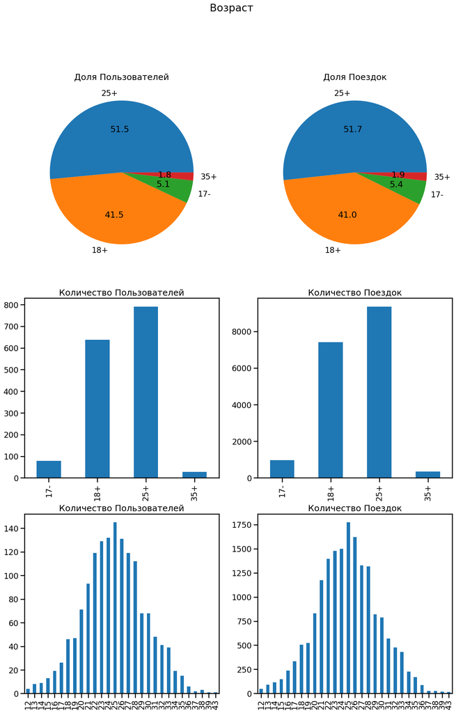

```python
fig1, ((ax1, ax2), (ax3, ax4), (ax5, ax6)) = plt.subplots(3, 2, figsize=(16, 23))
fig1.suptitle('Возраст')
udf.age_cat.value_counts().plot.pie(ylabel='', autopct='%.1f', title='Доля Пользователей', ax=ax1);
crudf.age_cat.value_counts().plot.pie(ylabel='', autopct='%.1f', title='Доля Поездок', ax=ax2);
udf.age_cat.value_counts(sort=False).sort_index().plot.bar(ylabel='', title='Количество Пользователей', ax=ax3);
crudf.age_cat.value_counts(sort=False).sort_index().plot.bar(ylabel='', title='Количество Поездок', ax=ax4);
udf.age.value_counts(sort=False).sort_index().plot.bar(ylabel='', title='Количество Пользователей', ax=ax5);
crudf.age.value_counts(sort=False).sort_index().plot.bar(ylabel='', title='Количество Поездок', ax=ax6);
plt.show()
```

**Вывод**

В терминах теории вероятностей пользователи возраст распределён нормально с о мат ожиданием около 25 лет. Говоря иначе большинство наших пользователей от 17 до 33 лет. Возраст не оказывает очевидное влияние на количество поездок среди пользователей.

### 3.4. Расстояние, которое пользователь преодолел за одну поездку

```python
crudf[crudf.distance > 1.5 * st.iqr(crudf.distance) + crudf.distance.quantile(.75)].shape[0]
```

```
126
```

```python
crudf[crudf.distance > 2 * st.iqr(crudf.distance) + crudf.distance.quantile(.75)].shape[0]
```

```
23
```

```python
crudf[crudf.distance > 2 * st.iqr(crudf.distance) + crudf.distance.quantile(.75)]
```

|  | user_id | distance | duration | date | month | name | age | city | subscription_type | age_cat |
| --- | --- | --- | --- | --- | --- | --- | --- | --- | --- | --- |
| 7043 | 737 | 6386.938020 | 25.967345 | 2021-07-31 | 7 | Мелания | 27 | Ростов-на-Дону | False | 25+ |
| 7635 | 782 | 6395.396068 | 28.982735 | 2021-02-22 | 2 | Мария | 24 | Омск | False | 18+ |
| 7830 | 795 | 6262.302747 | 0.500000 | 2021-09-09 | 9 | Владислава | 29 | Екатеринбург | False | 25+ |
| 7913 | 803 | 6427.053056 | 16.854106 | 2021-01-05 | 1 | Тамара | 30 | Пятигорск | False | 25+ |
| 8527 | 850 | 6436.625605 | 34.746502 | 2021-12-27 | 12 | Данила | 32 | Краснодар | False | 25+ |
| 9288 | 907 | 6251.726079 | 19.862075 | 2021-07-26 | 7 | Анжелика | 23 | Ростов-на-Дону | False | 18+ |
| 9756 | 941 | 6251.393925 | 26.754182 | 2021-11-06 | 11 | Данила | 28 | Екатеринбург | False | 25+ |
| 10341 | 981 | 6671.969833 | 27.297078 | 2021-12-06 | 12 | Ярослав | 17 | Ростов-на-Дону | False | 17- |
| 10663 | 1004 | 6383.036257 | 27.149109 | 2021-07-13 | 7 | Амина | 21 | Сочи | False | 18+ |
| 10915 | 1022 | 6535.386520 | 30.008799 | 2021-10-14 | 10 | Антонина | 14 | Сочи | False | 17- |
| 11189 | 1043 | 6456.423906 | 26.521413 | 2021-02-22 | 2 | Оксана | 28 | Москва | False | 25+ |
| 11319 | 1052 | 6503.600402 | 26.008309 | 2021-07-01 | 7 | Вячеслав | 27 | Пятигорск | False | 25+ |
| 11385 | 1057 | 6601.197575 | 0.500000 | 2021-02-07 | 2 | Адель | 26 | Москва | False | 25+ |
| 12086 | 1108 | 6538.937375 | 29.649276 | 2021-09-27 | 9 | Элина | 24 | Краснодар | False | 18+ |
| 13701 | 1224 | 6414.516026 | 0.500000 | 2021-07-15 | 7 | Александр | 25 | Пятигорск | False | 25+ |
| 14574 | 1285 | 6316.574814 | 0.500000 | 2021-09-25 | 9 | Станислав | 27 | Пятигорск | False | 25+ |
| 15580 | 1361 | 6908.491343 | 23.816983 | 2021-03-27 | 3 | Тамерлан | 21 | Екатеринбург | False | 18+ |
| 16278 | 1409 | 6306.531557 | 24.199632 | 2021-02-19 | 2 | Юрий | 29 | Екатеринбург | False | 25+ |
| 16309 | 1411 | 7211.007745 | 0.500000 | 2021-04-15 | 4 | Александр | 20 | Пятигорск | False | 18+ |
| 16484 | 1422 | 7066.003772 | 23.619318 | 2021-02-12 | 2 | Светлана | 33 | Тюмень | False | 25+ |
| 16679 | 1434 | 6258.822183 | 28.035289 | 2021-05-24 | 5 | Юрий | 35 | Тюмень | False | 35+ |
| 17171 | 1471 | 6760.940067 | 32.043760 | 2021-08-03 | 8 | Роман | 21 | Краснодар | False | 18+ |
| 17242 | 1477 | 6724.932981 | 0.500000 | 2021-01-12 | 1 | Ян | 17 | Сочи | False | 17- |

```python
crudf[crudf.distance < -1.5 * st.iqr(crudf.distance) + crudf.distance.quantile(.25)].shape[0]
```

```
910
```

```python
crudf[crudf.distance < -2 * st.iqr(crudf.distance) + crudf.distance.quantile(.25)].shape[0]
```

```
50
```

```python
crudf[crudf.distance < -2 * st.iqr(crudf.distance) + crudf.distance.quantile(.25)]
```

|  | user_id | distance | duration | date | month | name | age | city | subscription_type | age_cat |
| --- | --- | --- | --- | --- | --- | --- | --- | --- | --- | --- |
| 6611 | 707 | 28.793204 | 14.143966 | 2021-09-12 | 9 | Артём | 27 | Сочи | False | 25+ |
| 6691 | 712 | 23.963062 | 2.053251 | 2021-11-22 | 11 | Дарья | 28 | Москва | False | 25+ |
| 6816 | 721 | 62.568138 | 7.178766 | 2021-09-25 | 9 | Андрей | 27 | Пятигорск | False | 25+ |
| 6850 | 724 | 30.473763 | 3.166221 | 2021-05-09 | 5 | Елизавета | 23 | Краснодар | False | 18+ |
| 7367 | 760 | 54.724068 | 8.164172 | 2021-10-13 | 10 | Иван | 22 | Ростов-на-Дону | False | 18+ |
| 7389 | 762 | 35.061903 | 7.087655 | 2021-05-27 | 5 | Ярослава | 34 | Ростов-на-Дону | False | 25+ |
| 7841 | 796 | 7.097072 | 10.026614 | 2021-11-26 | 11 | Алексей | 25 | Екатеринбург | False | 25+ |
| 8324 | 835 | 12.233115 | 4.034952 | 2021-09-19 | 9 | Эвелина | 30 | Москва | False | 25+ |
| 8658 | 861 | 6.784447 | 6.015656 | 2021-07-21 | 7 | Мария | 27 | Краснодар | False | 25+ |
| 8906 | 880 | 11.283615 | 2.035632 | 2021-03-28 | 3 | Евгений | 29 | Краснодар | False | 25+ |
| 9128 | 896 | 31.803410 | 8.079509 | 2021-03-16 | 3 | Наталия | 31 | Омск | False | 25+ |
| 9318 | 909 | 69.328135 | 8.148560 | 2021-12-14 | 12 | Константин | 20 | Екатеринбург | False | 18+ |
| 9395 | 915 | 70.460783 | 4.384332 | 2021-11-03 | 11 | Галина | 24 | Екатеринбург | False | 18+ |
| 9439 | 918 | 38.711151 | 11.165905 | 2021-06-08 | 6 | Владимир | 27 | Екатеринбург | False | 25+ |
| 9541 | 925 | 2.570787 | 3.011018 | 2021-10-19 | 10 | Всеволод | 28 | Ростов-на-Дону | False | 25+ |
| 9784 | 943 | 26.784378 | 5.053569 | 2021-12-29 | 12 | Ульяна | 21 | Краснодар | False | 18+ |
| 9927 | 952 | 34.287979 | 9.097966 | 2021-11-04 | 11 | Назар | 24 | Ростов-на-Дону | False | 18+ |
| 10349 | 982 | 43.690381 | 13.201648 | 2021-07-21 | 7 | Альберт | 21 | Сочи | False | 18+ |
| 11245 | 1047 | 51.662299 | 9.134771 | 2021-08-26 | 8 | Дмитрий | 23 | Сочи | False | 18+ |
| 11555 | 1069 | 0.855683 | 10.001902 | 2021-01-31 | 1 | Степан | 20 | Сочи | False | 18+ |
| 11566 | 1069 | 44.016496 | 13.110041 | 2021-06-20 | 6 | Степан | 20 | Сочи | False | 18+ |
| 11862 | 1091 | 15.630873 | 13.044660 | 2021-03-29 | 3 | Арсен | 24 | Краснодар | False | 18+ |
| 12109 | 1110 | 70.705880 | 11.157124 | 2021-01-05 | 1 | Олег | 19 | Краснодар | False | 18+ |
| 13294 | 1197 | 65.151002 | 9.139609 | 2021-08-04 | 8 | Артемий | 28 | Ростов-на-Дону | False | 25+ |
| 13543 | 1213 | 72.462020 | 12.149921 | 2021-07-27 | 7 | Александр | 19 | Екатеринбург | False | 18+ |
| 13638 | 1219 | 40.287856 | 8.109876 | 2021-09-19 | 9 | Ксения | 25 | Пятигорск | False | 25+ |
| 13690 | 1223 | 4.329506 | 4.008958 | 2021-05-22 | 5 | Злата | 22 | Тюмень | False | 18+ |
| 13940 | 1240 | 15.000606 | 10.045002 | 2021-08-20 | 8 | Анжелика | 25 | Ростов-на-Дону | False | 25+ |
| 14066 | 1250 | 66.340137 | 2.234142 | 2021-04-12 | 4 | Георгий | 13 | Краснодар | False | 17- |
| 14081 | 1251 | 41.212830 | 2.224797 | 2021-04-15 | 4 | Кирилл | 25 | Краснодар | False | 25+ |
| 14577 | 1285 | 70.464111 | 12.183819 | 2021-11-05 | 11 | Станислав | 27 | Пятигорск | False | 25+ |
| 14676 | 1293 | 30.586955 | 9.096590 | 2021-01-14 | 1 | Ксения | 23 | Омск | False | 18+ |
| 14774 | 1300 | 62.368389 | 11.287854 | 2021-05-29 | 5 | Мария | 25 | Омск | False | 25+ |
| 14880 | 1308 | 74.022094 | 7.261254 | 2021-10-25 | 10 | Каролина | 18 | Екатеринбург | False | 18+ |
| 14979 | 1315 | 58.861480 | 6.117723 | 2021-02-02 | 2 | Иван | 21 | Екатеринбург | False | 18+ |
| 15022 | 1317 | 73.528876 | 4.401067 | 2021-11-01 | 11 | Снежана | 24 | Омск | False | 18+ |
| 15104 | 1323 | 22.393227 | 7.061072 | 2021-10-25 | 10 | Алла | 22 | Тюмень | False | 18+ |
| 15151 | 1327 | 69.099872 | 3.345499 | 2021-03-27 | 3 | Алла | 22 | Пятигорск | False | 18+ |
| 15607 | 1362 | 46.560533 | 2.253967 | 2021-09-22 | 9 | Владимир | 24 | Екатеринбург | False | 18+ |
| 15626 | 1364 | 15.366168 | 6.057623 | 2021-08-22 | 8 | Ян | 31 | Тюмень | False | 25+ |
| 15633 | 1364 | 52.767230 | 8.263836 | 2021-12-03 | 12 | Ян | 31 | Тюмень | False | 25+ |
| 15870 | 1381 | 31.391295 | 14.099130 | 2021-06-29 | 6 | Дарина | 24 | Краснодар | False | 18+ |
| 16277 | 1409 | 60.522599 | 3.151306 | 2021-02-05 | 2 | Юрий | 29 | Екатеринбург | False | 25+ |
| 16409 | 1417 | 44.728663 | 10.127796 | 2021-09-20 | 9 | Мадина | 31 | Омск | False | 25+ |
| 16442 | 1419 | 41.282076 | 4.154808 | 2021-11-20 | 11 | Яромир | 21 | Екатеринбург | False | 18+ |
| 16539 | 1425 | 52.585376 | 6.262927 | 2021-06-23 | 6 | Лидия | 25 | Сочи | False | 25+ |
| 17173 | 1471 | 27.965145 | 3.093217 | 2021-10-06 | 10 | Роман | 21 | Краснодар | False | 18+ |
| 17414 | 1489 | 22.314412 | 6.074381 | 2021-10-06 | 10 | Алёна | 30 | Пятигорск | False | 25+ |
| 17646 | 1506 | 37.002836 | 4.170782 | 2021-06-27 | 6 | Регина | 29 | Сочи | False | 25+ |
| 17760 | 1514 | 75.573191 | 5.174400 | 2021-01-26 | 1 | Ева | 25 | Тюмень | False | 25+ |

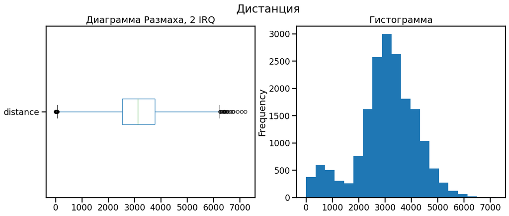

```python
fig1, axs = plt.subplots(1, 2, figsize = (16,6))
fig1.suptitle('Дистанция')
crudf.distance.plot.box(vert=False, whis = 2.0, title='Диаграмма Размаха, 2 IRQ', ax=axs[0]);
crudf.distance.plot.hist(ax=axs[1], title='Гистограмма', bins = 20);
plt.show()
```

**Вывод**

Правая половина близкое к нормальному распределение. Левая искажена большим количеством поездок меньше километра. В целом распределение похоже на два нормальных колокола - с падением около 1500 метров, что скорее всего говорит о том что поездки можно разделить на местные (<1500) и дальние (>1500).

Очень большой размах. Выбросы за 1.5 IRQ больше сотни вправо, почти тысяча влево. Даже за 2 IRQ десятки. Разные люди, разные города. Интересно что все выбросы без подписки. Правые выбросы - люди скорее всего катаются как развлечение или передают эстафетой. Левые - пробуют. И те и те выбрасывать на данной стадии не целесообразно так как их слишком много, чтобы говорить об аномалиях, и в целом дистанция располагает к большому разбросу.

### 3.5. Продолжительность поездок

```python
crudf[crudf.duration > 1.5 * st.iqr(crudf.duration) + crudf.duration.quantile(.75)].shape[0]
```

```
82
```

```python
crudf[crudf.duration > 2 * st.iqr(crudf.duration) + crudf.duration.quantile(.75)].shape[0]
```

```
6
```

```python
crudf[crudf.duration > 2 * st.iqr(crudf.duration) + crudf.duration.quantile(.75)]
```

|  | user_id | distance | duration | date | month | name | age | city | subscription_type | age_cat |
| --- | --- | --- | --- | --- | --- | --- | --- | --- | --- | --- |
| 143 | 15 | 4187.621459 | 38.125729 | 2021-01-13 | 1 | Валерия | 24 | Тюмень | True | 18+ |
| 1998 | 216 | 4831.339954 | 38.352763 | 2021-05-11 | 5 | Мадина | 26 | Сочи | True | 25+ |
| 2623 | 278 | 4754.433686 | 39.526602 | 2021-12-02 | 12 | Эдуард | 27 | Сочи | True | 25+ |
| 4215 | 454 | 5137.327103 | 40.823963 | 2021-12-27 | 12 | Вероника | 38 | Краснодар | True | 35+ |
| 4709 | 507 | 4645.642671 | 39.873856 | 2021-01-15 | 1 | Эвелина | 27 | Пятигорск | True | 25+ |
| 6453 | 694 | 4210.871467 | 38.265229 | 2021-03-11 | 3 | Алия | 29 | Краснодар | True | 25+ |

```python
crudf[crudf.duration < -1.5 * st.iqr(crudf.duration) + crudf.duration.quantile(.25)].shape[0]
```

```
95
```

```python
crudf[crudf.duration < -2 * st.iqr(crudf.duration) + crudf.duration.quantile(.25)].shape[0]
```

```
0
```

```python
crudf[crudf.duration < -1.6 * st.iqr(crudf.duration) + crudf.duration.quantile(.25)].shape[0]
```

```
95
```

```python
crudf[crudf.duration < -1.6 * st.iqr(crudf.duration) + crudf.duration.quantile(.25)].head(20)
```

|  | user_id | distance | duration | date | month | name | age | city | subscription_type | age_cat |
| --- | --- | --- | --- | --- | --- | --- | --- | --- | --- | --- |
| 6531 | 701 | 4196.445201 | 0.5 | 2021-08-31 | 8 | Иван | 31 | Екатеринбург | False | 25+ |
| 6570 | 704 | 4830.824371 | 0.5 | 2021-10-14 | 10 | Мирон | 29 | Ростов-на-Дону | False | 25+ |
| 6680 | 712 | 4684.004397 | 0.5 | 2021-03-04 | 3 | Дарья | 28 | Москва | False | 25+ |
| 6695 | 713 | 5215.642710 | 0.5 | 2021-02-25 | 2 | Святослав | 30 | Краснодар | False | 25+ |
| 6768 | 718 | 5197.436649 | 0.5 | 2021-02-11 | 2 | Владислава | 31 | Москва | False | 25+ |
| 6860 | 724 | 6225.520342 | 0.5 | 2021-12-16 | 12 | Елизавета | 23 | Краснодар | False | 18+ |
| 6883 | 726 | 4452.491518 | 0.5 | 2021-03-01 | 3 | Ольга | 22 | Пятигорск | False | 18+ |
| 7018 | 735 | 4406.954812 | 0.5 | 2021-04-13 | 4 | Кирилл | 18 | Пятигорск | False | 18+ |
| 7160 | 745 | 5286.167732 | 0.5 | 2021-08-17 | 8 | Борис | 21 | Ростов-на-Дону | False | 18+ |
| 7364 | 760 | 4881.391865 | 0.5 | 2021-08-29 | 8 | Иван | 22 | Ростов-на-Дону | False | 18+ |
| 7437 | 766 | 4539.088310 | 0.5 | 2021-12-22 | 12 | Алёна | 24 | Краснодар | False | 18+ |
| 7508 | 772 | 4718.820996 | 0.5 | 2021-05-22 | 5 | Григорий | 27 | Ростов-на-Дону | False | 25+ |
| 7537 | 774 | 5488.141903 | 0.5 | 2021-05-27 | 5 | Герман | 27 | Екатеринбург | False | 25+ |
| 7612 | 780 | 6112.644835 | 0.5 | 2021-11-23 | 11 | Семен | 13 | Тюмень | False | 17- |
| 7679 | 784 | 5202.815712 | 0.5 | 2021-06-03 | 6 | Светлана | 30 | Ростов-на-Дону | False | 25+ |
| 7791 | 792 | 5353.189287 | 0.5 | 2021-11-06 | 11 | Александр | 26 | Пятигорск | False | 25+ |
| 7830 | 795 | 6262.302747 | 0.5 | 2021-09-09 | 9 | Владислава | 29 | Екатеринбург | False | 25+ |
| 7883 | 800 | 5052.410425 | 0.5 | 2021-07-19 | 7 | Олег | 24 | Москва | False | 18+ |
| 7932 | 804 | 5547.830031 | 0.5 | 2021-05-10 | 5 | Тамерлан | 24 | Пятигорск | False | 18+ |
| 8329 | 836 | 4958.922077 | 0.5 | 2021-01-12 | 1 | Всеволод | 21 | Тюмень | False | 18+ |

Здесь явные ошибки. Заменим пропусками и попытаемся восстановить.

```python
crudf.loc[crudf.duration < -1.6 * st.iqr(crudf.duration) + crudf.duration.quantile(.25), 'duration'] = np.nan
nan_dur = crudf.duration.isna()
crudf.duration.isna().sum()
```

```
95
```

```python
not any(crudf[nan_dur].subscription_type)
```

```
True
```

```python
crudf[nan_dur].distance.min()
```

```
4030.308008428866
```

```python
crudf[nan_dur].distance.max()
```

```
7211.007744598519
```

```python
crudf.query('distance > 4000 and subscription_type == False').shape[0]
```

```
2603
```

```python
crudf.query('distance > 5000 and subscription_type == False').shape[0]
```

```
518
```

```python
crudf.query('distance > 6000 and subscription_type == False').shape[0]
```

```
46
```

```python
crudf[nan_dur].query('distance > 5000').shape[0]
```

```
50
```

```python
crudf[nan_dur].query('distance > 6000').shape[0]
```

```
10
```

```python
crudf.query('distance > 4500 and subscription_type == False').shape[0]
```

```
1289
```

Восстановим данные добавив столбец скорости, и заполним сначала его пропуски медианами из близких значений дистанции, а потом на основе их выставим продолжительность.

```python
crudf['speed'] = (crudf.distance/crudf.duration)
crudf.speed.isna().sum()
```

```
95
```

```python
crudf.query('distance > 4000 and subscription_type == False').speed.median()
```

```
209.57296634874808
```

```python
crudf.query('distance > 5000 and subscription_type == False').speed.median()
```

```
222.3593137905636
```

```python
crudf.query('3500 < distance < 5000  and subscription_type == False').speed.median()
```

```
197.64811984007616
```

```python
crudf.speed.median()
```

```
170.47391322231658
```

```python
for meters in range(4500, 6001, 500):
    crudf.loc[(crudf.distance < meters) & crudf.speed.isna(), ['speed']] =\
        crudf.query('@meters-1000 < distance < @meters+500 and subscription_type == False').speed.median()
crudf.speed.isna().sum()
```

```
10
```

```python
crudf[crudf.speed.isna()].distance.min()
```

```
6002.236437634401
```

```python
crudf.speed.fillna(crudf.query('5500 < distance and subscription_type == False').speed.median(), inplace=True)
crudf.speed.isna().sum()
```

```
0
```

```python
crudf.duration.mean()
```

```
17.896480405340395
```

```python
crudf.duration.fillna(crudf.distance/crudf.speed, inplace=True)
crudf.duration.mean()
```

```
17.929011062266603
```

```python
crudf[nan_dur].head(20)
```

|  | user_id | distance | duration | date | month | name | age | city | subscription_type | age_cat | speed |
| --- | --- | --- | --- | --- | --- | --- | --- | --- | --- | --- | --- |
| 6531 | 701 | 4196.445201 | 21.231900 | 2021-08-31 | 8 | Иван | 31 | Екатеринбург | False | 25+ | 197.648120 |
| 6570 | 704 | 4830.824371 | 23.303554 | 2021-10-14 | 10 | Мирон | 29 | Ростов-на-Дону | False | 25+ | 207.299895 |
| 6680 | 712 | 4684.004397 | 22.595305 | 2021-03-04 | 3 | Дарья | 28 | Москва | False | 25+ | 207.299895 |
| 6695 | 713 | 5215.642710 | 24.336424 | 2021-02-25 | 2 | Святослав | 30 | Краснодар | False | 25+ | 214.314263 |
| 6768 | 718 | 5197.436649 | 24.251473 | 2021-02-11 | 2 | Владислава | 31 | Москва | False | 25+ | 214.314263 |
| 6860 | 724 | 6225.520342 | 27.120637 | 2021-12-16 | 12 | Елизавета | 23 | Краснодар | False | 18+ | 229.549197 |
| 6883 | 726 | 4452.491518 | 22.527366 | 2021-03-01 | 3 | Ольга | 22 | Пятигорск | False | 18+ | 197.648120 |
| 7018 | 735 | 4406.954812 | 22.296973 | 2021-04-13 | 4 | Кирилл | 18 | Пятигорск | False | 18+ | 197.648120 |
| 7160 | 745 | 5286.167732 | 24.665497 | 2021-08-17 | 8 | Борис | 21 | Ростов-на-Дону | False | 18+ | 214.314263 |
| 7364 | 760 | 4881.391865 | 23.547488 | 2021-08-29 | 8 | Иван | 22 | Ростов-на-Дону | False | 18+ | 207.299895 |
| 7437 | 766 | 4539.088310 | 21.896240 | 2021-12-22 | 12 | Алёна | 24 | Краснодар | False | 18+ | 207.299895 |
| 7508 | 772 | 4718.820996 | 22.763258 | 2021-05-22 | 5 | Григорий | 27 | Ростов-на-Дону | False | 25+ | 207.299895 |
| 7537 | 774 | 5488.141903 | 25.607917 | 2021-05-27 | 5 | Герман | 27 | Екатеринбург | False | 25+ | 214.314263 |
| 7612 | 780 | 6112.644835 | 26.628910 | 2021-11-23 | 11 | Семен | 13 | Тюмень | False | 17- | 229.549197 |
| 7679 | 784 | 5202.815712 | 24.276572 | 2021-06-03 | 6 | Светлана | 30 | Ростов-на-Дону | False | 25+ | 214.314263 |
| 7791 | 792 | 5353.189287 | 24.978222 | 2021-11-06 | 11 | Александр | 26 | Пятигорск | False | 25+ | 214.314263 |
| 7830 | 795 | 6262.302747 | 27.280874 | 2021-09-09 | 9 | Владислава | 29 | Екатеринбург | False | 25+ | 229.549197 |
| 7883 | 800 | 5052.410425 | 23.574774 | 2021-07-19 | 7 | Олег | 24 | Москва | False | 18+ | 214.314263 |
| 7932 | 804 | 5547.830031 | 25.342817 | 2021-05-10 | 5 | Тамерлан | 24 | Пятигорск | False | 18+ | 218.911340 |
| 8329 | 836 | 4958.922077 | 23.921489 | 2021-01-12 | 1 | Всеволод | 21 | Тюмень | False | 18+ | 207.299895 |

Получился правдоподобный результат и среднее не слишком сдвинулось. Завершаем восстановление.

```python
crudf.drop(crudf[crudf.duration < -1.6 * st.iqr(crudf.duration) + crudf.duration.quantile(.25)].index, inplace=True)
```

```python
crudf[crudf.duration < -1.4 * st.iqr(crudf.duration) + crudf.duration.quantile(.25)].shape[0]
```

```
10
```

```python
crudf[crudf.duration < -1.4 * st.iqr(crudf.duration) + crudf.duration.quantile(.25)]
```

|  | user_id | distance | duration | date | month | name | age | city | subscription_type | age_cat | speed |
| --- | --- | --- | --- | --- | --- | --- | --- | --- | --- | --- | --- |
| 6691 | 712 | 23.963062 | 2.053251 | 2021-11-22 | 11 | Дарья | 28 | Москва | False | 25+ | 11.670789 |
| 6801 | 720 | 102.323624 | 2.292353 | 2021-09-20 | 9 | Сергей | 25 | Тюмень | False | 25+ | 44.636936 |
| 8906 | 880 | 11.283615 | 2.035632 | 2021-03-28 | 3 | Евгений | 29 | Краснодар | False | 25+ | 5.543051 |
| 10291 | 977 | 90.850696 | 2.320650 | 2021-08-15 | 8 | Амалия | 22 | Москва | False | 18+ | 39.148822 |
| 12016 | 1103 | 147.453884 | 2.315973 | 2021-02-26 | 2 | Вадим | 21 | Краснодар | False | 18+ | 63.668233 |
| 13308 | 1198 | 84.410014 | 2.180879 | 2021-06-11 | 6 | Демид | 29 | Ростов-на-Дону | False | 25+ | 38.704591 |
| 14066 | 1250 | 66.340137 | 2.234142 | 2021-04-12 | 4 | Георгий | 13 | Краснодар | False | 17- | 29.693792 |
| 14081 | 1251 | 41.212830 | 2.224797 | 2021-04-15 | 4 | Кирилл | 25 | Краснодар | False | 25+ | 18.524308 |
| 15607 | 1362 | 46.560533 | 2.253967 | 2021-09-22 | 9 | Владимир | 24 | Екатеринбург | False | 18+ | 20.657154 |
| 17309 | 1482 | 111.298857 | 2.222598 | 2021-07-24 | 7 | Глеб | 21 | Краснодар | False | 18+ | 50.076024 |

Здесь остаются более правдоподобные значения, оставим их.

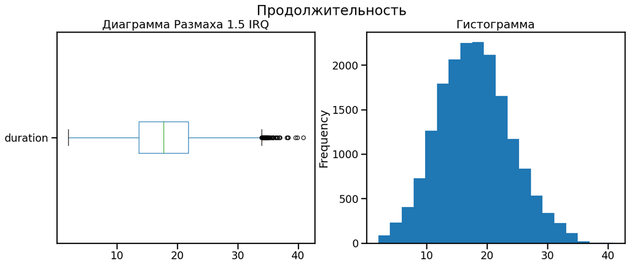

```python
fig1, axs = plt.subplots(1, 2, figsize = (16,6))
fig1.suptitle('Продолжительность')
crudf.duration.plot.box(vert=False, whis = 1.5 , title='Диаграмма Размаха 1.5 IRQ', ax=axs[0]);
crudf.duration.plot.hist(ax=axs[1], title='Гистограмма', bins = 20);
plt.show()
```

```python
(crudf.distance/crudf.duration).median()
```

```
170.8522494427599
```

Примечательно что все правые выбросы - люди с подпиской. Интересно также что мы тут не видим двух колоколов, как в дальности, что скорее всего значит, что разброс скоростей нарушает связь между временем и дистанцией.

### 3.6. Рассеяние продолжительности по дистанции

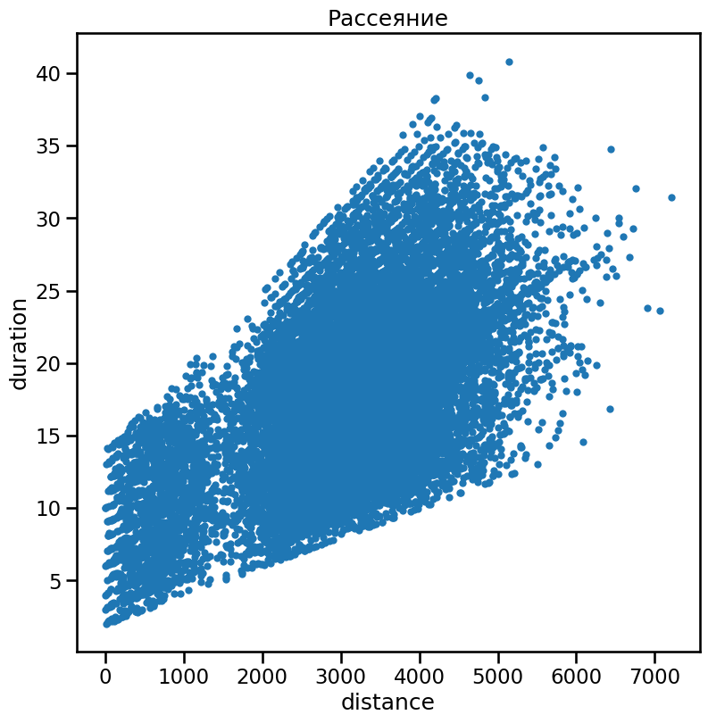

```python
crudf.plot.scatter('distance', 'duration' ,title='Рассеяние', figsize=(9,9));
```

**Вывод**

Гетероскедастичное рассеяние. Выбросы бросаются в глаза, но в целом находятся в рамках расширяющегося, стабильно, конуса. Прорежается в область 1500 метров, скорее всего говорит о том что поездки можно разделить на местные (<1500) и дальние (>1500).

### 3.7. Скорость

При восстановление пропусков продолжительно, был создан столбец скорости, ознакомимся с ним.

```python
crudf.speed /= 1000/60 # м/минуту -> км/час
```

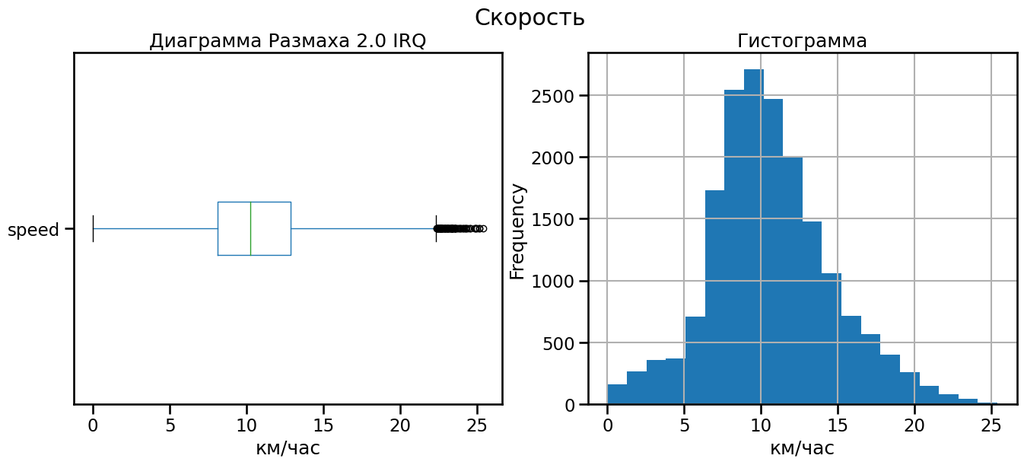

```python
#crudf.speed.hist().set(xlabel='км/час', title='Скорость');

fig1, axs = plt.subplots(1, 2, figsize = (16,6))
fig1.suptitle('Скорость')
crudf.speed.plot.box(vert=False, whis = 2.0 , title='Диаграмма Размаха 2.0 IRQ', ax=axs[0]);
crudf.speed.plot.hist(ax=axs[1], title='Гистограмма', bins = 20, grid=True);
axs[0].set(xlabel='км/час')
axs[1].set(xlabel='км/час')
plt.show()
```

```python
crudf.query('speed < 1').shape[0]
```

```
117
```

```python
crudf.query('speed < 1').sample(5)
```

|  | user_id | distance | duration | date | month | name | age | city | subscription_type | age_cat | speed |
| --- | --- | --- | --- | --- | --- | --- | --- | --- | --- | --- | --- |
| 17808 | 1517 | 180.812768 | 11.493126 | 2021-01-10 | 1 | Давид | 25 | Тюмень | False | 25+ | 0.943935 |
| 13638 | 1219 | 40.287856 | 8.109876 | 2021-09-19 | 9 | Ксения | 25 | Пятигорск | False | 25+ | 0.298065 |
| 12924 | 1169 | 84.880824 | 11.424404 | 2021-03-17 | 3 | Светлана | 27 | Ростов-на-Дону | False | 25+ | 0.445787 |
| 15445 | 1351 | 80.643639 | 6.179208 | 2021-09-05 | 9 | Захар | 22 | Ростов-на-Дону | False | 18+ | 0.783048 |
| 16442 | 1419 | 41.282076 | 4.154808 | 2021-11-20 | 11 | Яромир | 21 | Екатеринбург | False | 18+ | 0.596159 |

```python
crudf.query('speed > 25')
```

|  | user_id | distance | duration | date | month | name | age | city | subscription_type | age_cat | speed |
| --- | --- | --- | --- | --- | --- | --- | --- | --- | --- | --- | --- |
| 9099 | 894 | 5507.980168 | 13.015960 | 2021-11-30 | 11 | Григорий | 23 | Ростов-на-Дону | False | 18+ | 25.390275 |
| 14241 | 1261 | 5170.970011 | 12.341940 | 2021-01-29 | 1 | Давид | 22 | Пятигорск | False | 18+ | 25.138528 |
| 14310 | 1265 | 6088.051913 | 14.595969 | 2021-09-22 | 9 | Роман | 24 | Екатеринбург | False | 18+ | 25.026300 |
| 15332 | 1341 | 5215.548311 | 12.431097 | 2021-08-29 | 8 | Борис | 27 | Екатеринбург | False | 25+ | 25.173394 |

Аномалий не выявлено, вернёмся к графику.

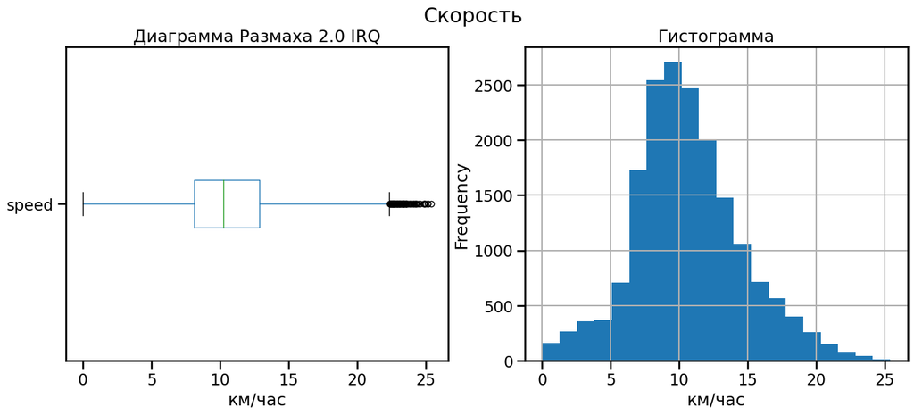

```python
#crudf.speed.hist().set(xlabel='км/час', title='Скорость');

fig1, axs = plt.subplots(1, 2, figsize = (16,6))
fig1.suptitle('Скорость')
crudf.speed.plot.box(vert=False, whis = 2.0 , title='Диаграмма Размаха 2.0 IRQ', ax=axs[0]);
crudf.speed.plot.hist(ax=axs[1], title='Гистограмма', bins = 20, grid=True);
axs[0].set(xlabel='км/час')
axs[1].set(xlabel='км/час')
plt.show()
```

**Вывод**

Скорость распределена нормально, довольно узкий колокол. Очень большой размах. Есть ряд поездок с очень низкой скоростью, сложно говорить аномалии ли это без технических характеристик самоката.

## 4. Шаг 4. Объединение данных

### 4.1. Единый датафрейм

Требуется закончить объединение данных в одну таблицу. Убедимся что все `subscription_type` представлены в обеих таблицах и проверим размеры до и после чтобы убелиться в отсутствии сбоев.

```python
all(crudf.subscription_type.sort_values().unique() == sdf.subscription_type.sort_values().unique())
```

```
True
```

```python
crudf.shape
```

```
(18068, 11)
```

```python
sdf.shape
```

```
(2, 4)
```

```python
sdf
```

|  | subscription_type | minute_price | start_ride_price | subscription_fee |
| --- | --- | --- | --- | --- |
| 0 | False | 8 | 50 | 0 |
| 1 | True | 6 | 0 | 199 |

```python
crudf = crudf.merge(sdf, on='subscription_type') # Не будем создавать новый, просто дополним.
#Начинать объединение с поездок лучше т.к. не нужно изменять таблицу чтобы изучать поездки.
```

```python
crudf.shape
```

```
(18068, 14)
```

```python
crudf.isnull().sum()
```

```
user_id              0
distance             0
duration             0
date                 0
month                0
name                 0
age                  0
city                 0
subscription_type    0
age_cat              0
speed                0
minute_price         0
start_ride_price     0
subscription_fee     0
dtype: int64
```

**Вывод**

Результат увеличился на 3 столбца, что и ожидалось. Пропусков нет. Объединение данных позволяет увидеть более полную картину.

### 4.2. Таблицы: с подпиской и без

```python
cfdf = crudf.query('subscription_type == False') # Complete Free
print('Пользователей без подписки:', cfdf.shape[0])
cfdf.head()
```

```
Пользователей без подписки: 11568
```

|  | user_id | distance | duration | date | month | name | age | city | subscription_type | age_cat | speed | minute_price | start_ride_price | subscription_fee |
| --- | --- | --- | --- | --- | --- | --- | --- | --- | --- | --- | --- | --- | --- | --- |
| 6500 | 700 | 2515.690719 | 14.944286 | 2021-01-02 | 1 | Айдар | 22 | Омск | False | 18+ | 10.100278 | 8 | 50 | 0 |
| 6501 | 700 | 846.932642 | 16.234663 | 2021-02-01 | 2 | Айдар | 22 | Омск | False | 18+ | 3.130090 | 8 | 50 | 0 |
| 6502 | 700 | 4004.434142 | 20.016628 | 2021-02-04 | 2 | Айдар | 22 | Омск | False | 18+ | 12.003323 | 8 | 50 | 0 |
| 6503 | 700 | 1205.911290 | 9.782872 | 2021-02-10 | 2 | Айдар | 22 | Омск | False | 18+ | 7.396057 | 8 | 50 | 0 |
| 6504 | 700 | 3047.379435 | 17.427673 | 2021-02-14 | 2 | Айдар | 22 | Омск | False | 18+ | 10.491519 | 8 | 50 | 0 |

```python
cpdf = crudf.query('subscription_type == True') # Complete Paid
print('Пользователей с подпиской Ультра:', cpdf.shape[0])
cpdf.head()
```

```
Пользователей с подпиской Ультра: 6500
```

|  | user_id | distance | duration | date | month | name | age | city | subscription_type | age_cat | speed | minute_price | start_ride_price | subscription_fee |
| --- | --- | --- | --- | --- | --- | --- | --- | --- | --- | --- | --- | --- | --- | --- |
| 0 | 1 | 4409.919140 | 25.599769 | 2021-01-01 | 1 | Кира | 22 | Тюмень | True | 18+ | 10.335841 | 6 | 0 | 199 |
| 1 | 1 | 2617.592153 | 15.816871 | 2021-01-18 | 1 | Кира | 22 | Тюмень | True | 18+ | 9.929620 | 6 | 0 | 199 |
| 2 | 1 | 754.159807 | 6.232113 | 2021-04-20 | 4 | Кира | 22 | Тюмень | True | 18+ | 7.260713 | 6 | 0 | 199 |
| 3 | 1 | 2694.783254 | 18.511000 | 2021-08-11 | 8 | Кира | 22 | Тюмень | True | 18+ | 8.734644 | 6 | 0 | 199 |
| 4 | 1 | 4028.687306 | 26.265803 | 2021-08-28 | 8 | Кира | 22 | Тюмень | True | 18+ | 9.202888 | 6 | 0 | 199 |

**Вывод**

Объединим данные, а потом разделим их по наиболее значимой категории мы можем получать полную информацию о пользователях без подписки и сравнивать её с подписчиками.

### 4.3. Визуализация

Требуется визуализировать и оценить данные пользователей обеих категорий.

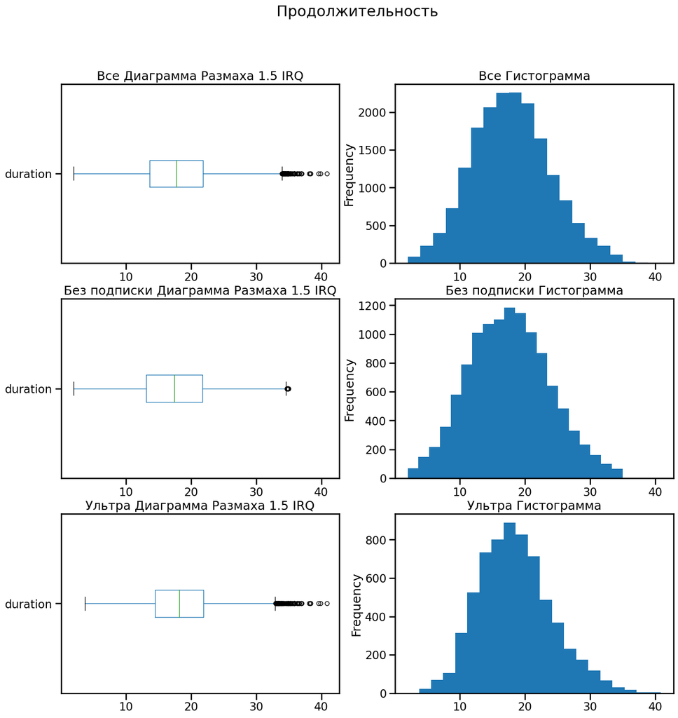

```python
fig1, axs = plt.subplots(3, 2, sharex='col', figsize = (16,16))
fig1.suptitle('Продолжительность')
crudf.duration.plot.box(vert=False, title='Все Диаграмма Размаха 1.5 IRQ', ax=axs[0,0]);
crudf.duration.plot.hist(title='Все Гистограмма', bins = 20, ax=axs[0, 1]);
cfdf.duration.plot.box(vert=False, title='Без подписки Диаграмма Размаха 1.5 IRQ', ax=axs[1,0]);
cfdf.duration.plot.hist(title='Без подписки Гистограмма', bins = 20, ax=axs[1, 1]);
cpdf.duration.plot.box(vert=False, title='Ультра Диаграмма Размаха 1.5 IRQ', ax=axs[2,0]);
cpdf.duration.plot.hist(title='Ультра Гистограмма', bins = 20, ax=axs[2, 1]);
for axx in fig1.axes:
        axx.tick_params(labelbottom=True)
plt.show()
```

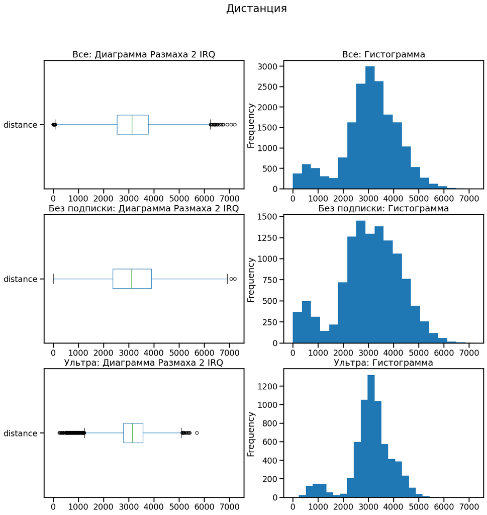

```python
fig1, axs = plt.subplots(3, 2, sharex='col', figsize = (16,16))
fig1.suptitle('Дистанция')
crudf.distance.plot.box(vert=False, whis=2, title='Все: Диаграмма Размаха 2 IRQ', ax=axs[0,0]);
crudf.distance.plot.hist(title='Все: Гистограмма', bins = 20, ax=axs[0, 1]);
cfdf.distance.plot.box(vert=False, whis=2, title='Без подписки: Диаграмма Размаха 2 IRQ', ax=axs[1,0]);
cfdf.distance.plot.hist(title='Без подписки: Гистограмма', bins = 20, ax=axs[1, 1]);
cpdf.distance.plot.box(vert=False, whis=2, title='Ультра: Диаграмма Размаха 2 IRQ', ax=axs[2,0]);
cpdf.distance.plot.hist(title='Ультра: Гистограмма', bins = 20, ax=axs[2, 1]);
for axx in fig1.axes:
        axx.tick_params(labelbottom=True)
plt.show()
```

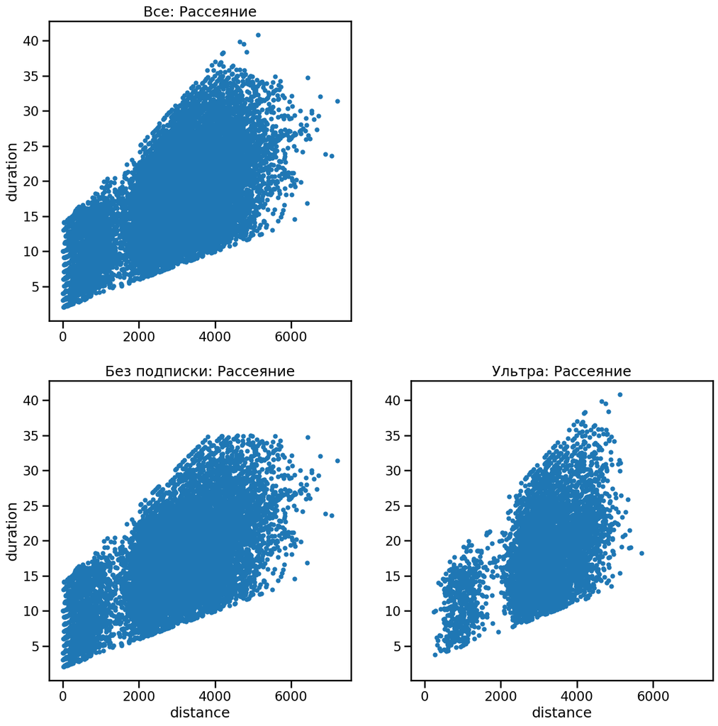

```python
fig1, axs = plt.subplots(2, 2, sharex=True, sharey=True, figsize=(15,15))
axs[0,1].axis('off')
crudf.plot.scatter('distance', 'duration' ,title='Все: Рассеяние', ax=axs[0,0])
cfdf.plot.scatter('distance', 'duration' ,title='Без подписки: Рассеяние', ax=axs[1,0])
cpdf.plot.scatter('distance', 'duration' ,title='Ультра: Рассеяние', ax=axs[1,1])
for axx in fig1.axes:
        axx.tick_params(labelbottom=True, labelleft=True)
plt.show()
```

**Вывод**

## 5. Шаг 5. Подсчёт выручки

В этом разделе требуется собрать данные в таблицу для подсчёта ежемесячной выручки.

### 5.1. Сборная таблица

Требуется составить таблицу собирающую данные о поездках пользователей в разные месяцы.

```python
adf = crudf.pivot_table(index=['user_id','month'], values=['distance', 'duration', 'date'], aggfunc={'distance':'sum','duration':'sum', 'date':'count'})
adf.columns=('count','total_distance','total_time')
adf.head(10)
```

| user_id | month | count | total_distance | total_time |
| --- | --- | --- | --- | --- |
| 1 | 1 | 2 | 7027.511294 | 41.416640 |
|  | 4 | 1 | 754.159807 | 6.232113 |
|  | 8 | 2 | 6723.470560 | 44.776802 |
|  | 10 | 2 | 5809.911100 | 31.578017 |
|  | 11 | 3 | 7003.499363 | 53.397424 |
|  | 12 | 2 | 6751.629942 | 27.203912 |
| 2 | 3 | 3 | 10187.723006 | 60.959959 |
|  | 4 | 2 | 6164.381824 | 39.048633 |
|  | 6 | 1 | 3255.338202 | 13.851127 |
|  | 7 | 2 | 6780.722964 | 46.170157 |

```python
adf.isnull().sum()
```

```
count             0
total_distance    0
total_time        0
dtype: int64
```

**Вывод**

Данная таблица уже довольна информативна и может показать нам сколько в месяц пользователи пользуются сервисом, однако для расчёта выручки потребуется больше информации.

### 5.2. Подсчёт выручки

Требуется добавить в таблицу данные о выручке за месяц. У нас нет данных о подписке в месяцы без поездок, будем считать что пользователи платят подписку только когда пользуются.

```python
crudf.shape[0]
```

```
18068
```

```python
crudf['duration'].apply(np.ceil)
```

```
0        26.0
1        16.0
2         7.0
3        19.0
4        27.0
         ...
18063    20.0
18064    22.0
18065    19.0
18066    17.0
18067    16.0
Name: duration, Length: 18068, dtype: float64
```

Для подсчёта прибыли удобно использовать оригинальную таблицу.

```python
crudf['ride_revenue'] = crudf['start_ride_price'] + crudf['duration'].apply(np.ceil) * crudf['minute_price']
crudf.head(10)
```

|  | user_id | distance | duration | date | month | name | age | city | subscription_type | age_cat | speed | minute_price | start_ride_price | subscription_fee | ride_revenue |
| --- | --- | --- | --- | --- | --- | --- | --- | --- | --- | --- | --- | --- | --- | --- | --- |
| 0 | 1 | 4409.919140 | 25.599769 | 2021-01-01 | 1 | Кира | 22 | Тюмень | True | 18+ | 10.335841 | 6 | 0 | 199 | 156.0 |
| 1 | 1 | 2617.592153 | 15.816871 | 2021-01-18 | 1 | Кира | 22 | Тюмень | True | 18+ | 9.929620 | 6 | 0 | 199 | 96.0 |
| 2 | 1 | 754.159807 | 6.232113 | 2021-04-20 | 4 | Кира | 22 | Тюмень | True | 18+ | 7.260713 | 6 | 0 | 199 | 42.0 |
| 3 | 1 | 2694.783254 | 18.511000 | 2021-08-11 | 8 | Кира | 22 | Тюмень | True | 18+ | 8.734644 | 6 | 0 | 199 | 114.0 |
| 4 | 1 | 4028.687306 | 26.265803 | 2021-08-28 | 8 | Кира | 22 | Тюмень | True | 18+ | 9.202888 | 6 | 0 | 199 | 162.0 |
| 5 | 1 | 2770.890808 | 16.650138 | 2021-10-09 | 10 | Кира | 22 | Тюмень | True | 18+ | 9.985109 | 6 | 0 | 199 | 102.0 |
| 6 | 1 | 3039.020292 | 14.927879 | 2021-10-19 | 10 | Кира | 22 | Тюмень | True | 18+ | 12.214811 | 6 | 0 | 199 | 90.0 |
| 7 | 1 | 2842.118050 | 23.117468 | 2021-11-06 | 11 | Кира | 22 | Тюмень | True | 18+ | 7.376547 | 6 | 0 | 199 | 144.0 |
| 8 | 1 | 3412.690668 | 15.238072 | 2021-11-14 | 11 | Кира | 22 | Тюмень | True | 18+ | 13.437490 | 6 | 0 | 199 | 96.0 |
| 9 | 1 | 748.690645 | 15.041884 | 2021-11-22 | 11 | Кира | 22 | Тюмень | True | 18+ | 2.986424 | 6 | 0 | 199 | 96.0 |

После этого данные о выручке добавим в сборную таблицу.

```python
adf['revenue'] = crudf.pivot_table(index=['user_id','month'], values='ride_revenue', aggfunc='sum')
adf['subscription_type'] = crudf.pivot_table(index=['user_id','month'], values='subscription_fee', aggfunc='mean')
adf['revenue'] += adf['subscription_type']
adf['subscription_type'] = adf['subscription_type'].astype('bool')
adf.head(10)
```

| user_id | month | count | total_distance | total_time | revenue | subscription_type |
| --- | --- | --- | --- | --- | --- | --- |
| 1 | 1 | 2 | 7027.511294 | 41.416640 | 451.0 | True |
|  | 4 | 1 | 754.159807 | 6.232113 | 241.0 | True |
|  | 8 | 2 | 6723.470560 | 44.776802 | 475.0 | True |
|  | 10 | 2 | 5809.911100 | 31.578017 | 391.0 | True |
|  | 11 | 3 | 7003.499363 | 53.397424 | 535.0 | True |
|  | 12 | 2 | 6751.629942 | 27.203912 | 367.0 | True |
| 2 | 3 | 3 | 10187.723006 | 60.959959 | 577.0 | True |
|  | 4 | 2 | 6164.381824 | 39.048633 | 439.0 | True |
|  | 6 | 1 | 3255.338202 | 13.851127 | 283.0 | True |
|  | 7 | 2 | 6780.722964 | 46.170157 | 487.0 | True |

**Вывод**

Таблица теперь позволяет сравнивать пользователей, прибыльность, и как поведение и доходы меняются из месяца в месяц. Так же мы в процессе добавили в сборную таблицу столбец отражающий тип подписки, что позволит сравнивать подписчиков с пользователями без подписки.

## 6. Шаг 6. Проверка гипотез

В этом разделе требуется проверить ряд гипотез на основе имеющихся данных. Таблица из пункта 5.2 содержит всю необходимую информации, будем работать на её основе.

Для стат анализа мы не можем с уверенностью подтвердить гипотезы, но можем проверить на предмет достоверности предложив противоположную как альтернативную, и посчитав вероятность наблюдений при условии что нулевая верна. Зададим общий для всех тестов уровень стат. значимости в 5%.

```python
stat_significance = .05
```

### 6.1. Время с подпиской больше чем без

*Задание:* Важно понять, тратят ли пользователи с подпиской больше времени на поездки? Если да, то пользователи с подпиской могут быть «выгоднее» для компании. Проверьте гипотезу. Используйте исходные данные о продолжительности каждой сессии — отдельно для подписчиков и тех, у кого нет подписки.

*Анализ:* Мы не можем подтвердить, что тратят, но мы можем проверить нет ли высокой вероятности отклонения в обратную сторону. Проведём Т-тест с нулевой гипотезой H_0 что они равны и альтернативной гипотезой H_1 говорящей о том, что пользователи с подпиской пользуются сервисом меньше времени чем пользователи без нее.

```python
result = st.ttest_ind(cpdf['duration'], cfdf['duration'],  alternative='less')
print(result)
if result.pvalue < stat_significance:
    print('Отвергаем нулевую гипотезу')
else:
    print('Не получилось отвергнуть нулевую гипотезу')
```

```
Ttest_indResult(statistic=10.361319967102762, pvalue=1.0)
Не получилось отвергнуть нулевую гипотезу
```

**Вывод**

Т-тест говорит, с очень большой вероятностью нулевая гипотеза обоснована и предпочтительней альтернативной. Это говорит о том что пользователи с подпиской пользуются сервисом столько же времени или больше, чем остальные.

### 6.2. Не больше 3130 метров с подпиской

*Задание:* Расстояние одной поездки в 3130 метров — оптимальное с точки зрения износа самоката. Можно ли сказать, что среднее расстояние, которое проезжают пользователи с подпиской за одну поездку, не превышает 3130 метров?

*Анализ:* Проведём t-тест, чтобы убедиться что подписчики проезжают в среднем данную дистанцию или меньше, для этого нулевой теорией примем что они равны, а альт гипотезой зададим что они проезжают больше 3130.

```python
result = st.ttest_1samp(cpdf.distance, 3130, alternative='greater')
print(result)
if result.pvalue < stat_significance:
    print('Отвергаем нулевую гипотезу')
else:
    print('Не получилось отвергнуть нулевую гипотезу')
```

```
Ttest_1sampResult(statistic=-1.402123166869486, pvalue=0.9195368847849785)
Не получилось отвергнуть нулевую гипотезу
```

**Вывод**

Статистически теория не опровергается, и шанс выборки попасть в заданный условиями интервал достаточно велик. Это говорит о том что не смотря на то что пользователи с подпиской больше пользуются сервисом, это, скорее всего, не приведёт к чрезмерному износу самокатов.

### 6.3. Выручка по месяцам с подпиской выше, чем без

*Задание:* Проверьте гипотезу о том, будет ли помесячная выручка от пользователей с подпиской по месяцам выше, чем выручка от пользователей без подписки.

*Анализ:*

Нулевой гипотезой примем что они равны.

Альтернативной будем считать гипотезу что прибыль от подписчиков меньше чем от других пользователей.

Проверим сначала по месяцам а потом для помесячной выручки в целом.

```python
ttest_by_month = [] #на случай если результаты понадобятся в дальнейшем.
rev_data_by_month = adf.droplevel('user_id').reset_index().set_index(['subscription_type','month']).sort_index() #Sort index чтобы избавиться от предупреждения
for month in range(1, 13):
    ttest_result = st.ttest_ind(
        rev_data_by_month.loc[(1, month), 'revenue'], # ultra
        rev_data_by_month.loc[(0, month), 'revenue'], # free
        alternative='less')
    print ('Месяц:', month)
    print(ttest_result)
    if ttest_result.pvalue < stat_significance:
        print('Отвергаем нулевую гипотезу')
    else:
        print('Не получилось отвергнуть нулевую гипотезу')

    ttest_by_month.append(ttest_result)
```

```
Месяц: 1
Ttest_indResult(statistic=4.303378233237667, pvalue=0.9999907527936868)
Не получилось отвергнуть нулевую гипотезу
Месяц: 2
Ttest_indResult(statistic=3.426377233959958, pvalue=0.9996800066157456)
Не получилось отвергнуть нулевую гипотезу
Месяц: 3
Ttest_indResult(statistic=1.9407726298060668, pvalue=0.9737093081271235)
Не получилось отвергнуть нулевую гипотезу
Месяц: 4
Ttest_indResult(statistic=2.8226880013254836, pvalue=0.9975677873790475)
Не получилось отвергнуть нулевую гипотезу
Месяц: 5
Ttest_indResult(statistic=3.7367782420957556, pvalue=0.9999013946237011)
Не получилось отвергнуть нулевую гипотезу
Месяц: 6
Ttest_indResult(statistic=3.426282443444711, pvalue=0.9996814094081574)
Не получилось отвергнуть нулевую гипотезу
Месяц: 7
Ttest_indResult(statistic=3.520235560555756, pvalue=0.9997741824714916)
Не получилось отвергнуть нулевую гипотезу
Месяц: 8
Ttest_indResult(statistic=2.5728119319977574, pvalue=0.9948805567298153)
Не получилось отвергнуть нулевую гипотезу
Месяц: 9
Ttest_indResult(statistic=2.630888910725778, pvalue=0.9956714694347073)
Не получилось отвергнуть нулевую гипотезу
Месяц: 10
Ttest_indResult(statistic=2.7840098454163575, pvalue=0.9972603111953359)
Не получилось отвергнуть нулевую гипотезу
Месяц: 11
Ttest_indResult(statistic=3.161835610031233, pvalue=0.9991900689525748)
Не получилось отвергнуть нулевую гипотезу
Месяц: 12
Ttest_indResult(statistic=2.7102702290963125, pvalue=0.9965779422103517)
Не получилось отвергнуть нулевую гипотезу
```

```python
rev_data_monthly = adf.droplevel('user_id').set_index('subscription_type')['revenue']
ttest_result = st.ttest_ind(
    rev_data_monthly[1], # ultra
    rev_data_monthly[0], # free
    alternative='less')
print(ttest_result)
if ttest_result.pvalue < stat_significance:
    print('Отвергаем нулевую гипотезу')
else:
    print('Не получилось отвергнуть нулевую гипотезу')
```

```
Ttest_indResult(statistic=10.704842856980148, pvalue=1.0)
Не получилось отвергнуть нулевую гипотезу
```

**Вывод**

В целом можно рекомендовать проводить акции по привлечению подписчиков так как исходя из этого и предыдущих пунктов они более выгодны компании.

### 6.4. Серверы мобильного приложения

*Задание:* Представьте такую ситуацию: техническая команда сервиса обновила сервера, с которыми взаимодействует мобильное приложение. Она надеется, что из-за этого количество обращений в техподдержку значимо снизилось. Некоторый файл содержит для каждого пользователя данные о количестве обращений до обновления и после него. Какой тест вам понадобился бы для проверки этой гипотезы?

*Анализ:* Учитывая что речь идёт об одних и тех же данных до и после вносимых измерений следует применить метод `st.ttest_rel(df_support_after, df_support_before, alternative='greater')`, так как он работает с related - связанными данными. Как и с другими задачами этого раздела мы не можем подтвердить что их будет меньше, но мы можем проверить гипотезу с альтернативной - в данном случае что послу будет больше чем до.

## 7. Шаг 7. Распределения

### 7.1. Промокоды

*Задание:* Отделу маркетинга GoFast поставили задачу: нужно провести акцию с раздачей промокодов на один бесплатный месяц подписки, в рамках которой как минимум 100 существующих клиентов должны продлить эту подписку. То есть по завершении периода действия подписки пользователь может либо отказаться от неё, либо продлить, совершив соответствующий платёж. Эта акция уже проводилась ранее и по итогу выяснилось, что после бесплатного пробного периода подписку продлевают 10 % пользователей. Выясните, какое минимальное количество промокодов нужно разослать, чтобы вероятность не выполнить план была примерно 5 %. Подберите параметры распределения, описывающего эту ситуацию, постройте график распределения и сформулируйте ответ на вопрос о количестве промокодов.

*Анализ:* У нас нет никакой информации о том как пользователи принимают решения кроме того что шанс успеха 10%, здесь разумно применить Биномиальное распределение, т.к. продление и не продление подписки это бинарное решение, где третьего не дано, т.е. эксперимент Бернулли. Используем именно его т.к. нас интересует необходимое количество попыток чтобы получить определённое число успехов - минимум 100 пользователей должны продлить подписку. В качестве ограничения выступает шанс не получить желаемое количество пользователей, он не должен превышать 5%.

```python
st.binom.cdf(100, 1172, 0.1)
```

```
0.04954795210203071
```

```python
st.binom.ppf(0.05, 1172, 0.1)
```

```
101.0
```

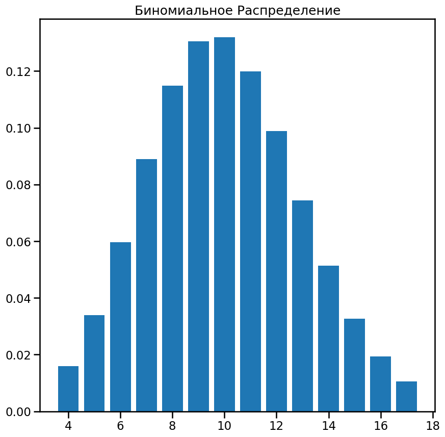

```python
n=100
p=0.1

fig, ax = plt.subplots(1, figsize=(10,10))

x = np.arange(st.binom.ppf(0.01, n, p),
              st.binom.ppf(0.99, n, p))
ax.bar(x, st.binom.pmf(x, n, p))
#ax.plot(x, st.binom.pmf(x, n, p), 'bo', ms=8, label='binom pmf')
#ax.vlines(x, 0, st.binom.pmf(x, n, p), colors='b', lw=5, stat_significance=0.5)
ax.set(title='Биномиальное Распределение');
```

**Вывод**

При условии что продлевают подписку 10% пользователей, чтобы получить 100 продлений с шансом как минимум 95%, нужно отправить как минимум 1172 промокода.

### 7.2. Push-уведомления

*Задание:* Отдел маркетинга рассылает клиентам push-уведомления в мобильном приложении. Клиенты могут открыть его или не открывать. Известно, что уведомления открывают около 40% получивших клиентов. Отдел планирует разослать 1 млн уведомлений. С помощью аппроксимации постройте примерный график распределения и оцените вероятность того, что уведомление откроют не более 399,5 тыс. пользователей.

*Анализ:* От нас требуется, с использованием аппроксимации, построить примерный график вероятности открытия пользователями push-уведомлений из рассылки. Размер рассылки - 1000000, открывают 40% уведомлений. После этого нужно выяснить шанс, что откроют не более 399,5 тыс пользователей. Распределение снова биномиальное. Так как здесь интересует количество открывающих, будем использовать аппроксимацию нормальным.

```python
n = 10**6
p = 0.4

mu =  n * p
sigma = (n * p * (1-p)) ** (1/2)
```

```python
mu
```

```
400000.0
```

```python
sigma
```

```
489.89794855663564
```

```python
mu - 3*sigma
```

```
398530.3061543301
```

```python
mu + 3*sigma
```

```
401469.6938456699
```

`Mu +- 3*sigma` Находится в пределах [0, n] значит аппроксимация будет достаточно точной.

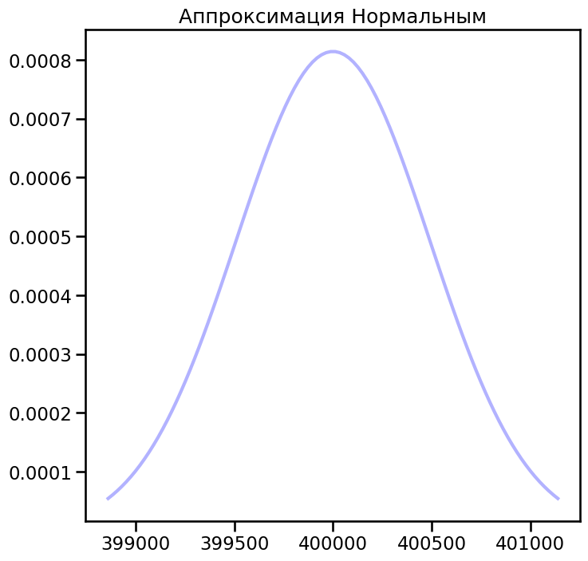

```python
fig, ax = plt.subplots(1, figsize=(8, 8))
x = np.linspace(st.norm.ppf(0.01, mu, sigma), st.norm.ppf(0.99, mu, sigma), 100)
ax.plot(x, st.norm.pdf(x, mu, sigma), 'b-', lw=3, alpha=0.3)
ax.set(title='Аппроксимация Нормальным');
```

```python
st.norm.cdf(399500, mu, sigma)
```

```
0.15371708296369768
```

**Вывод**

График нормального распределения - аппроксимации показывает что скорее всего откроет около 400000 пользователей, что соответствует математическому ожиданию. Шанс что откроют на 500 меньше, 399500, или еще меньше около 15%.

## 8. Общий Вывод

Целью проекта было проанализировать данные части пользователей сервиса аренды самокатов GoFast из нескольких городов и проверить ряд гипотез. В качестве данных для анализа предоставлены таблицы с пользователями, поездками и тарифами.

В процессе переработки данных возникло два замечания - среди пользователей есть дубликаты и отсутствие более полных данных о пользователях который не даёт возможности с уверенностью определить являются ли некоторые записи уникальными пользователями, или результатом человеческой ошибки или сбоя в системе.

Проведён анализ данных по категориям города, возраст и подписка. Было бы полезно уточнить насколько пропорциональны выбранные данные данным о пользователях в целом, но на их основе можно сказать что среди представленных городов пользователи распределены равномерно, пользователей без подписки немного больше и они значительно чаще совершают поездки, возраст в среднем среднего пользователя 25 лет.

По дистанции поездки можно разделить на две категории - менее 1500 м и более 1500 м, в то время кака около этого значения количество поездок падает, основная масса поездок - дальние, но есть также значительное количество коротких поездок. В данных о поездках была обнаружена аномалия - ряд записей отражал продолжительность поездки 0.5 минут, при этом дистанция поездок могла быть какой угодно. Скорее всего произошёл технический сбой на который стоит обратить внимание.

Также была составлена составлена таблица подсчета ежемесячной выручки каждого пользователя. Было бы полезно знать статус подписки пользователей в месяцы когда они не совершают поездок.

Воспользовавшись проверкой гипотез с помощью t-тестов, мы убедились, что пользователи-подписчики более выгодны компании, т.к. используют самокаты более продолжительное время, в основном ограничиваются дистанциями не приводящими к износу, и приносят больше прибыли. Для компании имеет смысл проводить акции с целью увеличить количество подписчиков.

С помощью распределений мы рассмотрели как можно предсказать результаты действий отдела маркетинга, это информацию можно использовать чтобы увеличить надёжность акций и рассылок.

В развитие бизнеса, следует сконцентрироваться на тарифах доступных в приложении, доля пользователей без подписок 54.4 %, их поездок 64%. Если предложить им другие варианты подписки, возможно удастся увеличить прибыль привлекая их чаще пользоваться сервисом.

Также следует обратить внимание на людей пользующихся самокатами для коротких поездок. Самый простой вариант - предложить подходящий тариф, что возможно увеличит частоту использования, и может даже привлечь больше пользователей. Также можно более детально изучить их поведение и места где часто совершают короткие поездки. Концентрация на них может так же снизить износ самокатов, что уменьшит затраты.

Также имеет смысл попытаться расширить базу пользователей, на данный момент подавляющее большинство около 20-30 лет например добавить функции в приложения чтобы привлечь пользователей моложе, еще лучше будет привлечь более возрастных клиентов, для этого можно сделать приложение более доступным, провести целевую рекламу.